# Machine Learning: Decision Trees

2017-06-11

# 1 Decision Trees

A [Decision Tree](https://en.wikipedia.org/wiki/Decision_tree) is a robust and transparent Machine Learning model. The tree starts with a single node and then branches out, with a decision being made at every branch point. The diagram below is a Decision Tree built with the data for passengers on the Titanic. It can be used to predict whether or not a particular passenger would have survived on the basis of their ticket class (`pclass`), gender, age, number of siblings or spouses aboard (`sibsp`) and number of parents or children aboard (`parch`). It’s apparent that during the construction of the tree the algorithm determined that only gender, age and `sibsp` were necessary to determine the fate of most passengers.

[figure not shown]

This is how one interprets the tree:

1. Start at the top node. Without any further information we see that there is a 62% chance that a passenger would have died and that 100% of the passengers are represented by this node.
2. Suppose that we are interested in Male passengers, so we follow the first branch to the left.
3. The next node tells us that 64% of the passengers were Male and that 81% of them died. Let’s get more specific.
4. Suppose that we are interested in Male passengers who were aged 9 years or younger, in which case we follow the branch to the right.
5. The next node tells us that 4% of the passengers satisfied these criteria and that they had a 53% probability of survival. Let’s get more specific.
6. Suppose that we are interested in Male passengers who were aged 9 years or younger and had three or more siblings on board. Now we follow the branch to the left.
7. The final node tells us that only 2% of the passengers satisfied these criteria and that 95% of them died. Male children in the same age group from smaller families had a much better chance of survival.

> … decision trees come closest to meeting the requirements for serving as an off-the-shelf procedure for data mining.Hastie, Tibshirani, and Friedman (2009)

Decision Trees have the following attractive characteristics:

- insensitive to the scale of features;
- resistant to irrelevant features and missing data; and
- produces a transparent, interpretable model.

However, it’s not all rosy. There are also some problems with Decision Trees:

- they tend to suffer from bias; and
- the algorithm is unstable.

## 1.1 Algorithm

Here’s a greedy algorithm for building a decision tree classifier. Suppose that the data are divided into two classes, denoted 0 and 1.

1. Initially assign all samples to the root node.
2. If all of the samples at this node have the same class then return this class as the result.
3. If no entropy reduction results from splitting on any of the features, then return the most frequent class as the result.
4. Identify which of the features results in a split with the largest entropy reduction. This is the *greedy* part of the algorithm in the sense that it aims to optimise for the current node and does not take into account the impact on subsequent nodes. It’s also the crux of the algorithm. The chosen feature will be the one that splits the data into two groups with maximum class purity per group.
5. Split the data for this node into two groups according to
- those records in class 0; and
- those records in class 1.
6. Form a new node from each group and apply algorithm to each of them.

The concept of *entropy* is important for selecting the splitting feature at each node. Entropy is a measure of class impurity. In a sense it is the opposite of information. If there are two classes, A and B, then the entropy is defined as
$$-p(A) * \log(p(A)) - p(B) * \log(p(B)).$$
Entropy is maximised when the two classes have equal probability (maximum uncertainty). Entropy is minimised when either A or B is zero, so that either one or the other of the classes is completely dominant. It can be thought of as a measure of impurity.

A reduction in entropy is equivalent to an increase in information.

## 1.2 Build a Human Decision Tree

Brace yourself, this is going to be fun.

## 1.3 Binary Classification

A Decision Tree can be built using `rpart()` from the `rpart` package. The code used to construct the tree above is:

```r
library(vcdExtra)
library(rpart)

(titanic.rpart <- rpart(survived ~ ., data = Titanicp, control = rpart.control(cp = 0.015)))
```

```
n= 1309

node), split, n, loss, yval, (yprob)
      * denotes terminal node

 1) root 1309 500 died (0.6180290 0.3819710)
   2) sex=male 843 161 died (0.8090154 0.1909846)
     4) age>=9.5 796 136 died (0.8291457 0.1708543) *
     5) age< 9.5 47  22 survived (0.4680851 0.5319149)
      10) sibsp>=2.5 20   1 died (0.9500000 0.0500000) *
      11) sibsp< 2.5 27   3 survived (0.1111111 0.8888889) *
   3) sex=female 466 127 survived (0.2725322 0.7274678) *
```

We have already encountered the `caret` package and seen how it provides a uniform interface to building models. It can also be used to construct Decision Trees using `rpart`.

```r
library(caret)

train(survived ~ ., data = Titanicp, method = "rpart", na.action = na.pass)
```

## 1.4 Multi-Class Classification

A Decision Tree easily generalises to classification models with more than two outcome classes.

```r
iris.rpart <- rpart(Species ~ ., data = iris)
```

This is what the decision tree for the `iris` data looks like:

[figure not shown]

Note that although it’s perfectly possible to produce a functional plot of a Decision Tree using the `plot()` function from the `rpart` package. The attractive visualisation above is make using `fancyRpartPlot()` from the `rattle` package.

## 1.5 Model Visualisation

It’s pretty obvious that Decision Trees lend themselves rather well to visualisation and, as a consequence, it’s pretty easy to interpret the information captured by the model. Wickham, Cook, and Hofmann (2015) talk about a range of general techniques for visualising models. Their work is not confined to any one model and is certainly worth looking at to gain a deeper understanding of how to use visualisation to interrogate a model.

We can also generate our own visualisations to plumb the depths of our models. For example, a Decision Tree will always divide the input space into [hyper-rectangles](https://en.wikipedia.org/wiki/Hyperrectangle) (multidimensional rectangles). This is a direct result of the fact that every decision point in the tree results in a binary outcome. To illustrate this fact, below is a cross-section through the `iris` data with shading indicating the outcome of the tree model trained above.

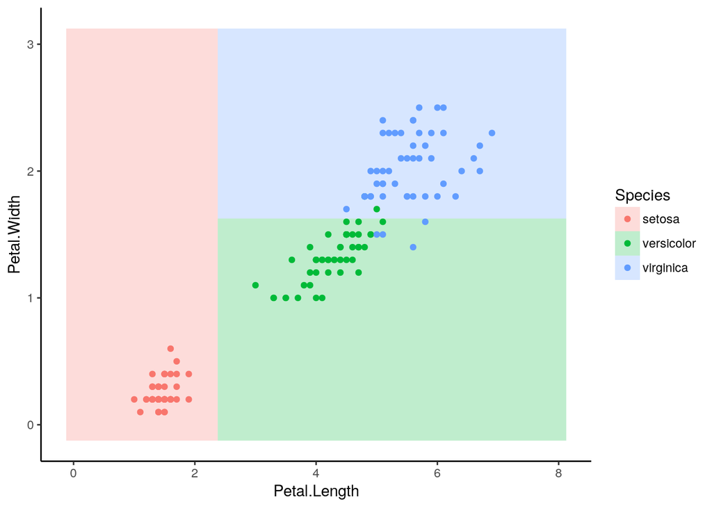

# 2 Conditional Inference Trees

The idea behind Conditional Inference Trees was introduced by Hothorn, Hornik, and Zeileis (2006). Like a conventional Decision Tree, a Conditional Inference Tree does a univariate split on the data at each node. However, whereas a Decision Tree tries to maximise an information measure at every node, the Conditional Inference Tree applies a statistical significance test. This is reflected in the fact that every node in a Conditional Inference Tree is associated with a p-value which gives the significance of the split at that node.

> The significance of the association between a nominal response and one of the covariates is investigated by a χ<sup>2</sup> test and the covariate with highest association is selected for splitting.Hothorn, Hornik, and Zeileis (2006)

In R a Conditional Inference Tree can be generated with `ctree()` from the `party` package. Alternatively we can use the interface provided by `caret`.

We’ll consider first the two class problem presented by the Titanic data. The display format for a Conditional Inference Tree is particularly informative since it gives the proportion of both classes in each of the terminal nodes.

```r
library(party)

titanic.ctree <- ctree(survived ~ ., data = Titanicp, controls = ctree_control(maxdepth = 3))
```

[figure not shown]

Moving on to a multiclass problem, the display format for the tree is changed but is equally informative.

```r
iris.ctree <- ctree(Species ~ ., data = iris)
```

[figure not shown]

# 3 Regression Trees

A Decision Tree can be used for regression too. The principal shortcoming of a regression tree though is the fact that the output is discrete: the number of possible values is limited to the number of terminal nodes (or “leaves”). This results in relatively poor accuracy and reduces the ability of a tree to model a smooth function.

We’ll generate a Regression Tree for the `prostate` data.

```r
library(ElemStatLearn)

prostate.rpart <- rpart(lpsa ~ ., data = prostate, subset = train)
```

Here’s what that tree looks like:

[figure not shown]

The interpretation of this tree is much the same as before. The root node does not make any assumptions about the data and simply assigns the average `lpsa` over the entire data set (this is the most reliable prediction in the absence of further information). The discrete predicted values in the terminal nodes make the point mentioned above: there are only six possible outcome values for this model.

We can also train a Conditional Inference Tree to fit a regression problem.

```r
prostate.ctree <- ctree(lpsa ~ ., data = prostate)
```

[figure not shown]

Here’s another example predicting `Salary` in the `baseball` data.

```r
library(corrgram)
library(dplyr)

baseball.ctree <- ctree(Salary ~ ., data = subset(baseball, !is.na(Salary)) %>% select(-logSal))
```

[figure not shown]

It’s also possible to train a Conditional Inference Tree usind the `caret` package.

```r
train(survived ~ ., data = Titanicp, method = "ctree", na.action = na.pass)
```

Note that we changed from an `rpart` model to a `ctree` model by simply changing the `method` parameter.

# 4 Unbalanced Data

Classification problems are often be plagued by unbalanced data, where the number of samples in one class far outweighs the number in the other class. Consider the following examples:

- A manufacturing process where on average only 1 in 10 000 units is defective.
- Admission to a prestigious university where only 1 in 50 candidates get shortlisted.
- The rare disease Fibrodysplasia Ossificans Progressiva affects approximately 1 in two million people.

These unbalanced data can have a profound negative effect on model performance, since the model is often biased towards the majority class. Algorithms that aim to optimise overall accuracy are probably the worst affected because the minority class has minimal effect on accuracy. Choosing an appropriate performance metric is paramount for unbalanced data.

An important consideration when dealing with unbalanced data is the relative cost of different types of errors.

There is a selection of techniques for dealing with unbalanced data. We’ll consider undersampling, oversampling and synthetic data generation.

To illustrate various techniques for dealing with unbalanced data, we’ll look at the `hacide` data from `ROSE`.

```r
library(ROSE)

data(hacide)
#
# Renaming the levels is important because predict.train() with type = "prob" does not work otherwise. Why?
#
levels(hacide.train$cls) <- c("neg", "pos")
levels(hacide.test$cls)  <- c("neg", "pos")
table(hacide.train$cls)
```

```
neg pos
980  20
```

Let’s make a simple decision tree model.

```r
fit.rpart <- train(cls ~ ., data = hacide.train, method = "rpart")
confusionMatrix(predict(fit.rpart, hacide.test), hacide.test$cls, positive = "pos")
```

```
Confusion Matrix and Statistics

          Reference
Prediction neg pos
       neg 245   4
       pos   0   1

               Accuracy : 0.984
                 95% CI : (0.9595, 0.9956)
    No Information Rate : 0.98
    P-Value [Acc > NIR] : 0.4387

                  Kappa : 0.3289
 Mcnemar's Test P-Value : 0.1336

            Sensitivity : 0.2000
            Specificity : 1.0000
         Pos Pred Value : 1.0000
         Neg Pred Value : 0.9839
             Prevalence : 0.0200
         Detection Rate : 0.0040
   Detection Prevalence : 0.0040
      Balanced Accuracy : 0.6000

       'Positive' Class : pos
```

The accuracy is very high indeed, but the model is focused on the negative class (which is in the majority in the training data). Let’s look at AUC to gauge the overall quality of the model.

```r
roc.curve(hacide.test$cls, predict(fit.rpart, hacide.test, type = "prob")[,2], plot = FALSE)
```

```
Area under the curve (AUC): 0.600
```

Well, that’s not very good at all!

## 4.1 Oversampling

Oversampling (or “upsampling”) inflates the number of observations from the minority class. Of course this approach will not result in any information loss. On the contrary, it results in duplication, which can lead to overfitting and poor generalisation.

As a first attempt to improve the `hacide` model, let’s oversample the minority class.

```r
hacide.oversampled <- ovun.sample(cls ~ ., data = hacide.train, method = "over", N = 1960, seed = 13)$data
table(hacide.oversampled$cls)
```

```
neg pos
980 980
```

We now have equal counts of both the positive and negative outcomes. Next we rebuild the model.

```r
fit.rpart.oversampled <- train(cls ~ ., data = hacide.oversampled, method = "rpart")
confusionMatrix(predict(fit.rpart.oversampled, hacide.test), hacide.test$cls, positive = "pos")
```

```
Confusion Matrix and Statistics

          Reference
Prediction neg pos
       neg 211   0
       pos  34   5

               Accuracy : 0.864
                 95% CI : (0.8152, 0.9039)
    No Information Rate : 0.98
    P-Value [Acc > NIR] : 1

                  Kappa : 0.1989
 Mcnemar's Test P-Value : 1.519e-08

            Sensitivity : 1.0000
            Specificity : 0.8612
         Pos Pred Value : 0.1282
         Neg Pred Value : 1.0000
             Prevalence : 0.0200
         Detection Rate : 0.0200
   Detection Prevalence : 0.1560
      Balanced Accuracy : 0.9306

       'Positive' Class : pos
```

Immediately we can see that this is a much better model: it’s picking up all of the positive outcomes. However, at the same time, there are many more false positives. Note that the total number of samples in the test data has not been changed. We only upsampled the training data.

## 4.2 Undersampling

Undersampling (or “downsampling”) reduces the number of observations from the majority class. This approach runs the risk of losing important information regarding the majority class.

Let’s look at the effect of undersampling the majority class in the `hacide` data.

```r
hacide.undersampled <- ovun.sample(cls ~ ., data = hacide.train, method = "under", N = 40, seed = 13)$data
table(hacide.undersampled$cls)
```

```
neg pos
 20  20
```

Again we end up with a balance between positive and negative outcomes but this time around we have far less data to train on. We’ll give it a whirl anyway.

```r
fit.rpart.undersampled <- train(cls ~ ., data = hacide.undersampled, method = "rpart")
confusionMatrix(predict(fit.rpart.undersampled, hacide.test), hacide.test$cls, positive = "pos")
```

```
Confusion Matrix and Statistics

          Reference
Prediction neg pos
       neg 182   1
       pos  63   4

               Accuracy : 0.744
                 95% CI : (0.6852, 0.7969)
    No Information Rate : 0.98
    P-Value [Acc > NIR] : 1

                  Kappa : 0.0767
 Mcnemar's Test P-Value : 2.44e-14

            Sensitivity : 0.8000
            Specificity : 0.7429
         Pos Pred Value : 0.0597
         Neg Pred Value : 0.9945
             Prevalence : 0.0200
         Detection Rate : 0.0160
   Detection Prevalence : 0.2680
      Balanced Accuracy : 0.7714

       'Positive' Class : pos
```

That’s not too bad either: the majority of positive outcomes are being successfully predicted by the model. However the number of false positives has become even worse.

We can apply both approaches in parallel: undersampling the majority class (without replacement) and oversampling the minority class (with replacement). In this case we can specify both the number of samples in the final population as well as the proportion of the minority class.

```r
hacide.both <- ovun.sample(cls ~ ., data = hacide.train, method = "both", p = 0.25, N = 500, seed = 13)$data
table(hacide.both$cls)
```

```
neg pos
376 124
```

```r
fit.rpart.both <- train(cls ~ ., data = hacide.both, method = "rpart")
```

## 4.3 Synthetic Data Generation

Synthetic data generation is a form of oversampling which aims to avoid redundant data. The Synthetic Minority Over-sampling Technique (SMOTE), developed by Chawla et al. (2002), is a popular algorithm for generating synthetic data. SMOTE uses bootstrap resampling and nearest neighbours. The algorithm looks roughly something like this:

1. Find the difference between one feature vector and it’s nearest neighbour.
2. Scale the difference vector by a random number between 0 and 1.
3. Add the scaled difference vector to the original feature vector.

In effect the new datum lies on the line segment between an existing feature vector and its nearest neighbour.

Another approach to generating synthetic data is Randomly Over Sampling Examples (ROSE), developed by Lunardon, Menardi, and Torelli (2014), which uses a smoothed bootstrap algorithm.

Now let’s take a look at generating some synthetic data for `hacide`. First we’ll use ROSE.

```r
hacide.synthetic.rose <- ROSE(cls ~ ., data = hacide.train, N = 200, seed = 13)$data
table(hacide.synthetic.rose$cls)
```

```
neg pos
101  99
```

```r
fit.rpart.rose <- train(cls ~ ., data = hacide.synthetic.rose, method = "rpart")
```

We’ll also run SMOTE. The parameters for ROSE and SMOTE have been chosen to give a similar number of samples in each outcome class.

```r
library(DMwR)

hacide.synthetic.smote <- SMOTE(cls ~ ., data = hacide.train, perc.over = 400, perc.under = 125)
table(hacide.synthetic.smote$cls)
```

```
neg pos
100 100
```

```r
fit.rpart.smote <- train(cls ~ ., data = hacide.synthetic.smote, method = "rpart")
```

Finally let’s compare the performance of the various models on the test data.

```
                     fit       AUC
1         fit.rpart.both 0.5375510
2              fit.rpart 0.6000000
3 fit.rpart.undersampled 0.7885714
4  fit.rpart.oversampled 0.9444898
5         fit.rpart.rose 0.9444898
6        fit.rpart.smote 0.9632653
```

It’s apparent that oversampling, ROSE and SMOTE give the best results.

# 5 Exercises

1. Complete the iris modelling exercise. This is a *multiclass* problem. Some models support multiclass problems, others don’t. Decision trees do. Divide the data in a 60% training and 40% testing split. Create a model based on the training data.
- What is the accuracy of your training model on you training set?
- What are the most important node splits in your model? Use rattle’s `fancyRpartPlot()` function to visualize your model.
- What is the accuracy of your model on your testing set?
2. Using the Pima Indians Diabetes data (`PimaIndiansDiabetes` or `PimaIndiansDiabetes2`) from the `mlbench` package.
- Install and load the `mlbench` package.
- Use `data(PimaIndiansDiabetes)` to load the data.
- Divide the data set into an 80% training and 20% testing split.
- Make a model that achieves 100% accuracy on your training set.
- Apply that model to your test set.
- What is the accuracy of the model on your testing set?
- Conceptually, why is this model so much worse on the testing data?
- What would you do differently to avoid this problem?
3. Use a decision tree to make a regression for crime in the `Boston` data from the `MASS` package. Compare its RMSE (use `rmse()` from the `Metrics` package) to the RMSE from a simple linear regression model. Which one is better? Why?

# Resources

Chawla, Nitesh V, Kevin W Bowyer, Lawrence O Hall, and W Philip Kegelmeyer. 2002. “SMOTE: Synthetic Minority Over-sampling Technique Nitesh.” *Journal of Artificial Intelligence Research* 16: 321–57. doi:10.1613/jair.953.

Hastie, Trevor, Robert Tibshirani, and Jerome Friedman. 2009. *The Elements of Statistical Learning*.

Hothorn, Torsten, Kurt Hornik, and Achim Zeileis. 2006. “Unbiased recursive partitioning: A conditional inference framework.” *Journal of Computational and Graphical Statistics* 15 (July): 651–74. doi:10.1198/106186006X133933.

Lunardon, Nicola, Giovanna Menardi, and Nicola Torelli. 2014. “ROSE : A Package for Binary Imbalanced Learning.” *The R Journal* 6: 79–89.

Wickham, Hadley, Dianne Cook, and Heike Hofmann. 2015. “Visualizing Statistical Models: Removing the Blindfold.” *Statistical Analysis and Data Mining* 8 (4): 203–25. doi:10.1002/sam.11271.